# Day 1-B Activity (Exploratory Data Analysis)

# Load Packages

```r
if (!require("tidyverse")) {install.packages("tidyverse"); require("tidyverse")}
if (!require("summarytools")) {install.packages("summarytools"); require("summarytools")}
if (!require("psych")) {install.packages("psych"); require("psych")}
if (!require("psychTools")) {install.packages("psychTools"); require("psychTools")}
if (!require("caret")) {install.packages("caret"); require("caret")}
if (!require("mice")) {install.packages("mice"); require("mice")}
if (!require("VIM")) {install.packages("VIM"); require("VIM")}
if (!require("corrplot")) {install.packages("corrplot"); require("corrplot")}
```

# Load Data

This activity will use the ‘globalWarm’ dataset from the ‘psychTools’ package, a dataset exploring the relationships between emotions, ideology, and party affiliation as predictors of attitudes towards government action on climate change.

1. Load in the ‘globalWarm’ dataset:

(optional: read a bit about this dataset using ?globalWarm)

# Data Split

2. Split the dataset into a training set (80%) and testing set (20%).
3. Name the training set ‘globalWarm_train’ and the test set ‘globalWarm_test’.
4. Check the dimensions of your training and test set to make sure the splitting was done accurately.

Remember to set a seed so your results are reproducible!

(hint: the outcome variable of interest is ‘govact’)

# EDA: Data distributions and error detection

5. Explore basic summary statistics and data distributions using the dfSummary() function. Feel free to explore summary statistics and data distributions using other functions as well!
6. Write a few sentences describing your observations about the dataset and variables. Are there any extreme values, nonsensical values, inconsistencies, variables with low variance, or outliers?

# EDA: Missing Data

As you can see, the dataset does not have any missing values. For the purposes of this exercise, let’s insert some missingness to explore by running this line of code:

```r
globalWarm_train_ampute <- ampute(globalWarm_train, prop = 0.4, mech = "MAR")
globalWarm_train_m <- globalWarm_train_ampute$amp
```

Now, use data visualizations to inspect missingness in the dataset. Specifically,

7. How much missing data is there? (hint: aggregation plot)
8. Do missing data systematically vary by other observed data? (hint: spineplots/spinograms/mosiac plots)
9. Are there any patterns of missingness across the entire dataset? (hint: parallel coordinate plots)

# EDA: Correlations

10. Inspect the correlation matrix. Are there any highly correlated features? What about clusters of correlated features? Any features that are particularly correlated with the outcome?

# EDA: Shape of relationships

11. Use a scatterplot matrix to examine the shape of relationships between features and the outcome variable. Do the relationships look linear or nonlinear?

# Conclusions

12. In a few sentences, please describe what you learned about this dataset through these exploratory data analyses.
13. What are some ideas you have for using this knowledge to inform your feature engineering and modeling decisions?

## Answer key

**Click here to view the answer key to the hands-on activity**

```r
data('globalWarm') # 1
```

```r
set.seed(2021)
trainIndex <- createDataPartition(globalWarm$govact, p = .8,
                                  list = FALSE,
                                  times = 1) # 2
globalWarm_train <- globalWarm[trainIndex, ] # 3
globalWarm_test <- globalWarm[-trainIndex, ] # 4

dim(globalWarm_train)
```

```
## [1] 653   7
```

```r
dim(globalWarm_test)
```

```
## [1] 162   7
```

```r
print(dfSummary(globalWarm_train), method = 'render') # 5
```

Data Frame Summary

globalWarm_train

**Dimensions**: 653 x 7  
**Duplicates**: 1

| **No** | **Variable** | **Stats / Values** | **Freqs (% of Valid)** | **Graph** | **Valid** | **Missing** |
| --- | --- | --- | --- | --- | --- | --- |
| 1 | govact [numeric] | Mean (sd) : 4.6 (1.4) min < med < max: 1 < 4.8 < 7 IQR (CV) : 1.6 (0.3) | 31 distinct values |  | 653 (100.0%) | 0 (0.0%) |
| 2 | posemot [numeric] | Mean (sd) : 3.1 (1.4) min < med < max: 1 < 3 < 6 IQR (CV) : 2 (0.4) | 16 distinct values |  | 653 (100.0%) | 0 (0.0%) |
| 3 | negemot [numeric] | Mean (sd) : 3.5 (1.5) min < med < max: 1 < 3.7 < 6 IQR (CV) : 2.3 (0.4) | 16 distinct values |  | 653 (100.0%) | 0 (0.0%) |
| 4 | ideology [numeric] | Mean (sd) : 4.1 (1.6) min < med < max: 1 < 4 < 7 IQR (CV) : 2 (0.4) | 1 : 28 ( 4.3% ) 2 : 88 ( 13.5% ) 3 : 79 ( 12.1% ) 4 : 234 ( 35.8% ) 5 : 86 ( 13.2% ) 6 : 86 ( 13.2% ) 7 : 52 ( 8.0% ) |  | 653 (100.0%) | 0 (0.0%) |
| 5 | age [numeric] | Mean (sd) : 49.6 (16.4) min < med < max: 18 < 51 < 87 IQR (CV) : 28 (0.3) | 67 distinct values |  | 653 (100.0%) | 0 (0.0%) |
| 6 | sex [numeric] | Min : 0 Mean : 0.5 Max : 1 | 0 : 334 ( 51.1% ) 1 : 319 ( 48.9% ) |  | 653 (100.0%) | 0 (0.0%) |
| 7 | partyid [numeric] | Mean (sd) : 1.9 (0.9) min < med < max: 1 < 2 < 3 IQR (CV) : 2 (0.5) | 1 : 287 ( 44.0% ) 2 : 137 ( 21.0% ) 3 : 229 ( 35.1% ) |  | 653 (100.0%) | 0 (0.0%) |

Generated by summarytools 0.9.9 ([R](https://www.r-project.org/) version 4.1.0)  
2021-07-18

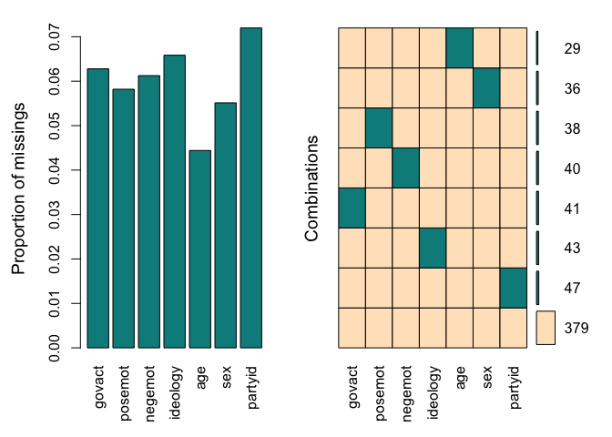

```r
# add some missingness
globalWarm_train_ampute <- ampute(globalWarm_train, prop = 0.4, mech = "MAR")
globalWarm_train_m <- globalWarm_train_ampute$amp

aggr(globalWarm_train_m, numbers = TRUE, prop = c(TRUE, FALSE), col = c("bisque", "darkcyan")) # 7
```

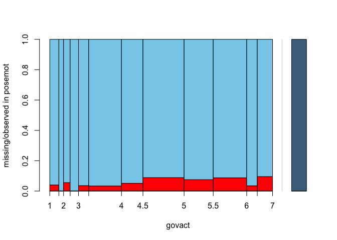

```
##
## Click in in the left margin to switch to the previous variable or in the right margin to switch to the next variable.
## To regain use of the VIM GUI and the R console, click anywhere else in the graphics window.
```

```r
spineMiss(globalWarm_train_m[, c("govact", "posemot")], miss.labels = FALSE) # 8 (example with govact and posemot variables)
```

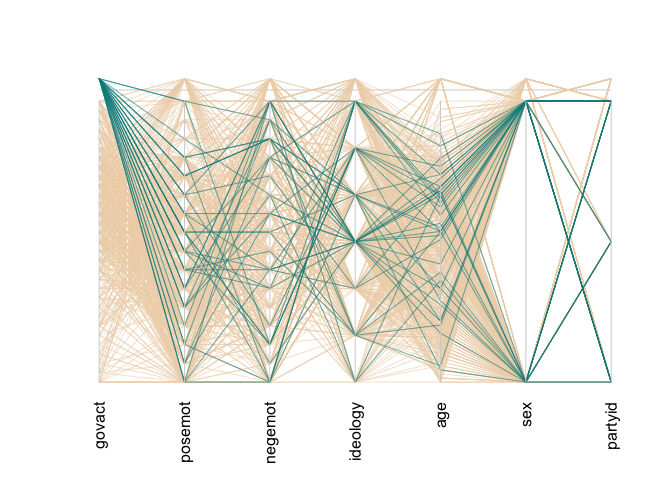

```
##
## Click on a coordinate axis to add to or remove from the highlight selection.
## Click in the top margin to toggle visualizing missing  values in the plot variables.
## To regain use of the VIM GUI and the R console, click in any of the other plot margins.
##
## Highlighted 'missings' in variable 'govact'.
```

```r
parcoordMiss(globalWarm_train_m, highlight = 'govact', alpha = 0.6, col = c("bisque2","darkcyan")) # 9 (example with govact highlighted)
```

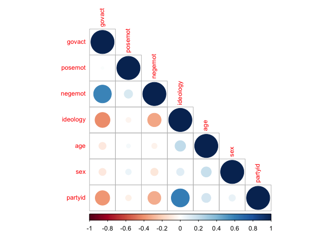

```r
cormat <- cor(globalWarm_train_m, use = "pairwise.complete.obs")
corrplot(cormat, type = 'lower', tl.cex = 0.8) # 10
```

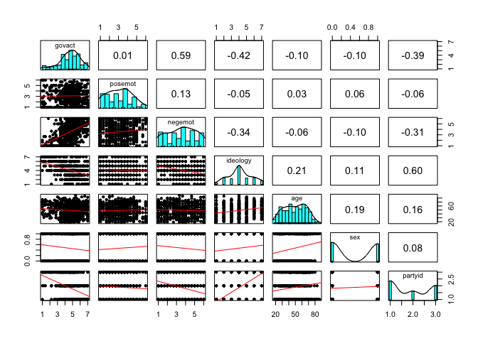

```r
pairs.panels(globalWarm_train_m, method = 'pearson', density = TRUE, ellipses = FALSE,
             lm = TRUE, cex.cor = 0.8, cex.labels = 0.9) #11
```